# Calibration ensemble training on random subsets of different sizes

```r
library(ggplot2)
library(dplyr)
```

Experiment code is in the file calibration_subsets_sizes_experiment.py This experiment trains CalibrationEnsemble on random subsets of different sizes picked from the neural networks training set. Each subset size is tested several times. The goal of the experiment is to determine the best calibration subset size.

Following are results for networks trained on CIFAR-10 training set with 500 samples extracted as a validation set.

```r
base_dir_tc <- "../data/data_train_val_c10/0/exp_subsets_sizes_calibration_outputs/"
metrics_ens_tc <- read.csv(file.path(base_dir_tc, "ens_metrics.csv"), stringsAsFactors=TRUE)
metrics_net_tc <- read.csv(file.path(base_dir_tc, "net_metrics.csv"), stringsAsFactors=TRUE)
metrics_net_cal_tc <- read.csv(file.path(base_dir_tc, "net_cal_metrics.csv"))
```

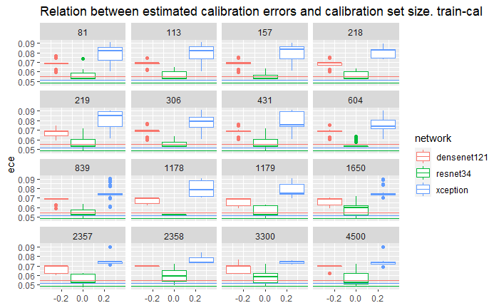

```r
net_calibrations_ece <- ggplot() + geom_boxplot(data=metrics_net_cal_tc, mapping=aes(y=ece, color=network)) +
  geom_hline(data=metrics_net_tc, mapping=aes(yintercept=ece, color=network)) + facet_wrap(~train_size) +
  ggtitle("Relation between estimated calibration errors and calibration set size. train-cal")
net_calibrations_ece
```

As we can see, calibration on training data worsens the estimated calibration error of the networks.

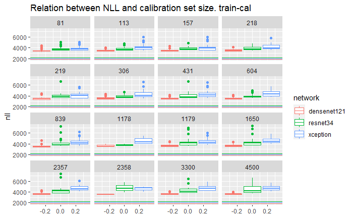

```r
net_calibrations_nll <- ggplot() + geom_boxplot(data=metrics_net_cal_tc, mapping=aes(y=nll, color=network)) +
  geom_hline(data=metrics_net_tc, mapping=aes(yintercept=nll, color=network)) + facet_wrap(~train_size) +
  ggtitle("Relation between NLL and calibration set size. train-cal")
net_calibrations_nll
```

Calibration on training data also worsens the negative log likelihood.

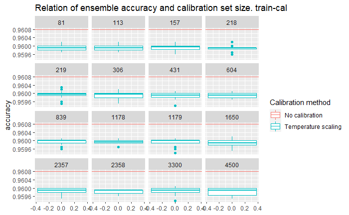

```r
ens_accuracy <- ggplot() + geom_boxplot(data=(metrics_ens_tc %>% filter(calibrating_method != "NoCalibration")),
                                        mapping=aes(y=accuracy, color="Temperature scaling")) +
  geom_hline(data=(metrics_ens_tc %>% filter(calibrating_method == "NoCalibration") %>% select(!train_size)),
             mapping=aes(yintercept=accuracy, color="No calibration")) +
  facet_wrap(~train_size) +
  guides(color=guide_legend(title="Calibration method")) +
  ggtitle("Relation of ensemble accuracy and calibration set size. train-cal")
ens_accuracy
```

Calibration on train data worsens the ensemble accuracy.

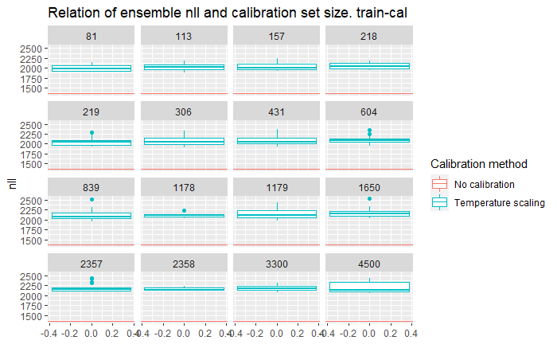

```r
ens_nll <- ggplot() + geom_boxplot(data=(metrics_ens_tc %>% filter(calibrating_method != "NoCalibration")),
                                        mapping=aes(y=nll, color="Temperature scaling")) +
  geom_hline(data=(metrics_ens_tc %>% filter(calibrating_method == "NoCalibration") %>% select(!train_size)),
             mapping=aes(yintercept=nll, color="No calibration")) +
  facet_wrap(~train_size) +
  guides(color=guide_legend(title="Calibration method")) +
  ggtitle("Relation of ensemble nll and calibration set size. train-cal")
ens_nll
```

Calibration on train data worsens the ensemble nll.

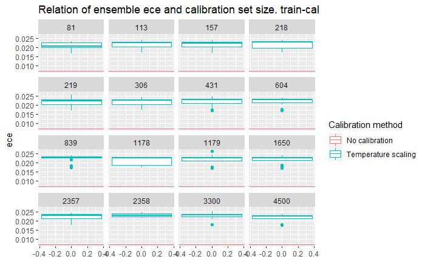

```r
ens_ece <- ggplot() + geom_boxplot(data=(metrics_ens_tc %>% filter(calibrating_method != "NoCalibration")),
                                        mapping=aes(y=ece, color="Temperature scaling")) +
  geom_hline(data=(metrics_ens_tc %>% filter(calibrating_method == "NoCalibration") %>% select(!train_size)),
             mapping=aes(yintercept=ece, color="No calibration")) +
  facet_wrap(~train_size) +
  guides(color=guide_legend(title="Calibration method")) +
  ggtitle("Relation of ensemble ece and calibration set size. train-cal")
ens_ece
```

Calibration on train data worsens the ensemble estimated calibration error.

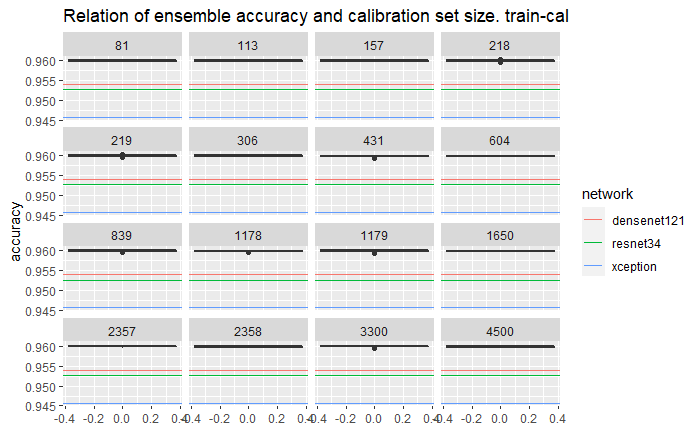

```r
ens_accuracy <- ggplot() + geom_boxplot(data=(metrics_ens_tc %>% filter(calibrating_method != "NoCalibration")),
                                        mapping=aes(y=accuracy)) +
  geom_hline(data=metrics_net_tc,
             mapping=aes(yintercept=accuracy, color=network)) +
  facet_wrap(~train_size) +
  ggtitle("Relation of ensemble accuracy and calibration set size. train-cal")
ens_accuracy
```

Since calibration on training data proved to be contraproduktive, we also tested calibration on validation data. Networks in these plots are different - trained on just a half of CIFAR 10 training set.

```r
base_dir_vc <- "../data/data_train_val_half_c10/0/exp_subsets_sizes_calibration_outputs/"
metrics_ens_vc <- read.csv(file.path(base_dir_vc, "ens_metrics.csv"), stringsAsFactors=TRUE)
metrics_net_vc <- read.csv(file.path(base_dir_vc, "net_metrics.csv"), stringsAsFactors=TRUE)
metrics_net_cal_vc <- read.csv(file.path(base_dir_vc, "net_cal_metrics.csv"))
```

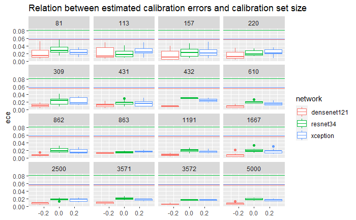

```r
net_calibrations_ece <- ggplot() + geom_boxplot(data=metrics_net_cal_vc, mapping=aes(y=ece, color=network)) +
  geom_hline(data=metrics_net_vc, mapping=aes(yintercept=ece, color=network)) + facet_wrap(~train_size) +
  ggtitle("Relation between estimated calibration errors and calibration set size")
net_calibrations_ece
```

Calibration on validation set improves estimated calibration error on test set. Ece is lower and more stable with larger calibration set size.

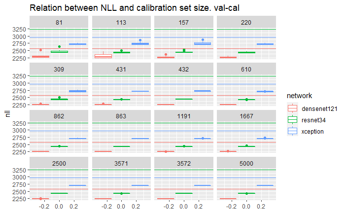

```r
net_calibrations_nll <- ggplot() + geom_boxplot(data=metrics_net_cal_vc, mapping=aes(y=nll, color=network)) +
  geom_hline(data=metrics_net_vc, mapping=aes(yintercept=nll, color=network)) + facet_wrap(~train_size) +
  ggtitle("Relation between NLL and calibration set size. val-cal")
net_calibrations_nll
```

Calibration on validation data lowers the nll. There is not much difference for increasing calibration set size except for lowering the variance.

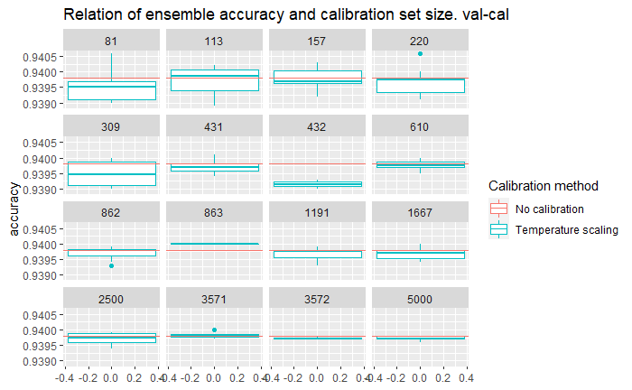

```r
ens_accuracy <- ggplot() + geom_boxplot(data=(metrics_ens_vc %>% filter(calibrating_method != "NoCalibration")),
                                        mapping=aes(y=accuracy, color="Temperature scaling")) +
  geom_hline(data=(metrics_ens_vc %>% filter(calibrating_method == "NoCalibration") %>% select(!train_size)),
             mapping=aes(yintercept=accuracy, color="No calibration")) +
  facet_wrap(~train_size) +
  guides(color=guide_legend(title="Calibration method")) +
  ggtitle("Relation of ensemble accuracy and calibration set size. val-cal")
ens_accuracy
```

Calibration on validation data almost in all cases lowered the median ensemble accuracy.

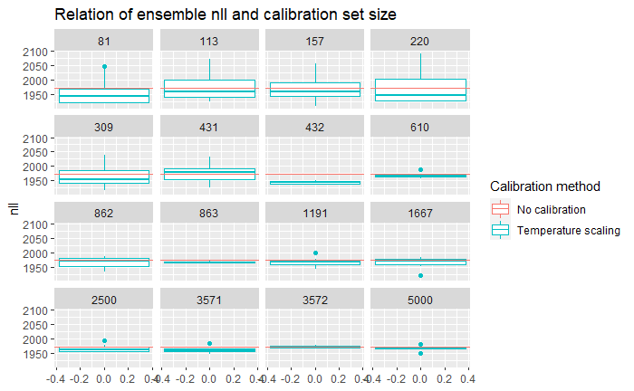

```r
ens_nll <- ggplot() + geom_boxplot(data=(metrics_ens_vc %>% filter(calibrating_method != "NoCalibration")),
                                        mapping=aes(y=nll, color="Temperature scaling")) +
  geom_hline(data=(metrics_ens_vc %>% filter(calibrating_method == "NoCalibration") %>% select(!train_size)),
             mapping=aes(yintercept=nll, color="No calibration")) +
  facet_wrap(~train_size) +
  guides(color=guide_legend(title="Calibration method")) +
  ggtitle("Relation of ensemble nll and calibration set size")
ens_nll
```

Improvement of ensemble NLL with calibration on validation data is small or nonexistent.

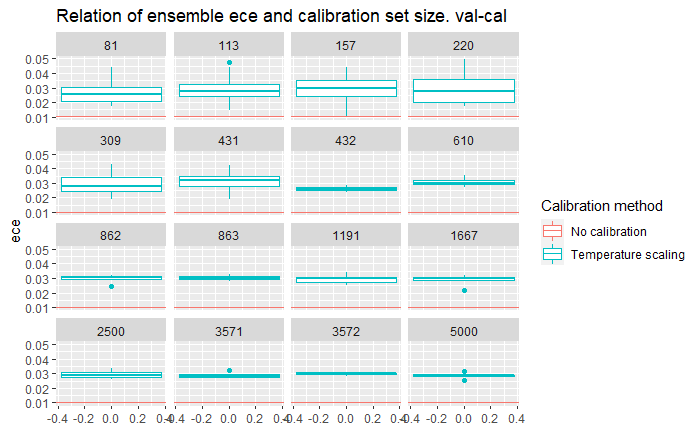

```r
ens_ece <- ggplot() + geom_boxplot(data=(metrics_ens_vc %>% filter(calibrating_method != "NoCalibration")),
                                        mapping=aes(y=ece, color="Temperature scaling")) +
  geom_hline(data=(metrics_ens_vc %>% filter(calibrating_method == "NoCalibration") %>% select(!train_size)),
             mapping=aes(yintercept=ece, color="No calibration")) +
  facet_wrap(~train_size) +
  guides(color=guide_legend(title="Calibration method")) +
  ggtitle("Relation of ensemble ece and calibration set size. val-cal")
ens_ece
```

Calibration on validation data worsens the ensemble estimated calibration error.

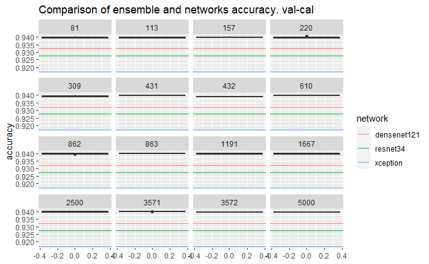

```r
ens_accuracy <- ggplot() + geom_boxplot(data=(metrics_ens_vc %>% filter(calibrating_method != "NoCalibration")),
                                        mapping=aes(y=accuracy)) +
  geom_hline(data=metrics_net_vc,
             mapping=aes(yintercept=accuracy, color=network)) +
  facet_wrap(~train_size) +
  ggtitle("Comparison of ensemble and networks accuracy. val-cal")
ens_accuracy
```